# Teotihuacan AMM, Script #1:

Data Prep and Dataset Construction

Rudolf Cesaretti

Last run on 2022-11-09

This R markdown document : Topographic/environmental metrics

1. Calculate catchment area variables, including
   - Topographic/environmental metrics
2. Reorganize the data and export for Script #6

# 1 Setup

All of the data and scripts are downloadable from the [new Teotihuacan AMM Analysis github repository](https://https://github.com/rcesaret/TeotihuacanAMM), which can be cloned to your own account/computer or downloaded directly as a .zip folder.

Either way, once you have done so, you will need to modify the working directory (setwd(“C:/…)”) path and “dir” variables in the code chunk below to match the repository location on your computer.

```r
wd <- list()

# SET YOUR LOCAL DIRECTORY LOCATION HERE: wd$dir <-
# 'C:/Users/rcesaret/Dropbox (ASU)/TeotihuacanDean/TeotihuacanAMM/'
wd$dir <- "C:/Users/TJ McMote/Dropbox (ASU)/TeotihuacanDean/TeotihuacanAMM/"

wd$analysis <- paste0(wd$dir, "analysis/")
wd$data_r <- paste0(wd$dir, "data-raw/")
wd$data_p <- paste0(wd$dir, "data-processed/")
wd$data_f <- paste0(wd$dir, "data-final-outputs/")
wd$figs <- paste0(wd$dir, "figures/")
wd$funcs <- paste0(wd$dir, "functions/")
```

## 1.1 Load R Packages and Custom Functions

```r
# Package names
packages <- c("rgdal", "rgeos", "sp", "sf", "GISTools", "raster", "tidyverse",
    "tidyr", "ggnewscale", "cowplot", "kableExtra")
# 'spatialEco','purrr','stars','data.table', 'Matrix', 'gdistance',
# 'lwgeom',

# Install packages not yet installed
installed_packages <- packages %in% rownames(installed.packages())
if (any(installed_packages == FALSE)) {
    install.packages(packages[!installed_packages])
}

# load packages
invisible(lapply(packages, library, character.only = TRUE))

rm(packages, installed_packages)

# Read in custom R functions located in the wd$funcs directory folder
FUNCS <- list("HelperFunctions.R", "CalcRingData.R")
invisible(lapply(FUNCS, function(x) source(paste0(wd$funcs, x))))
rm(FUNCS)
```

## 1.2 Import Data

Data we are importing:

Refer to metadata

The primary class spatial data format used in this script is the Spatial Polygon Dataframe (spdf) class from the “sp” R package. While I frequently switch back-and-forth to the “Simple Features” (sf) class from the “sf” R package data, I make sure to revert to Spatial Polygon Dataframe (spdf) after all sf calculations.

We will be working in the coordinate reference system (CRS; projection) WGS84 / UTM Zone 14N (ESPG:32614) for the entirety of this analysis.

```r
# TMP Architectural interpretation points
TeoArch_Pts <- read.csv(paste0(wd$data_r, "TeoArchDataPts.csv"))

# TMP Architecture polygons
TeoArch_Poly <- invisible(readOGR(paste0(wd$data_r, "TMPArchPoly.gpkg")))
# Added Open Space Arch Features <- readOGR(paste0(wd$data_r,'.gpkg'))

# TMP Rings -- Orig, repositioned, rectangular
RingsPoly_Circle <- invisible(readOGR(paste0(wd$data_r, "RingsPoly_Circle.gpkg")))
RingsPoly_Oval <- invisible(readOGR(paste0(wd$data_r, "RingsPoly_Oval.gpkg")))
# TMP survey limit polygon
TMP_MapPoly <- invisible(readOGR(paste0(wd$data_r, "TMP_Map_Poly_Extent.gpkg")))
```

## 1.3 Variables

### 1.3.1 Architectural Classifications

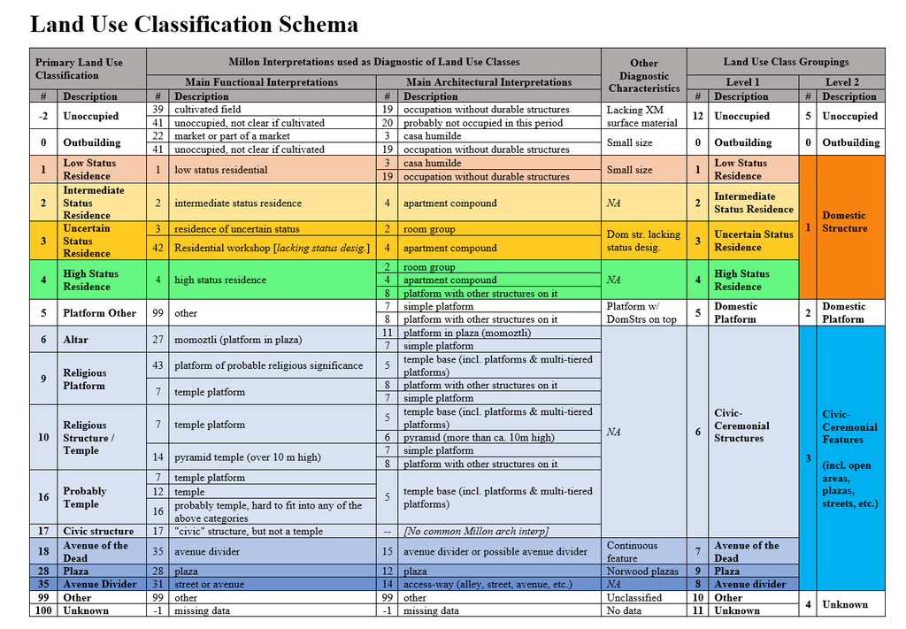

## 1.4 Data Integration

```r
## Modify some existing variables RingsPoly_Oval@data$Dist <-
## as.numeric(RingsPoly_Oval@data$Dist)
names(TeoArch_Pts)[names(TeoArch_Pts) == "Area_ha"] <- "Area_ha_Pts"
names(TeoArch_Pts)[names(TeoArch_Pts) == "Area_m2"] <- "Area_m2_Pts"
names(TeoArch_Pts)[names(TeoArch_Pts) == "Ring"] <- "Ring_Circle"
TeoArch_Poly@data$FID_1 <- as.numeric(TeoArch_Poly@data$FID_1)
names(TeoArch_Poly@data)[names(TeoArch_Poly@data) == "FID_1"] <- "ID"
names(TeoArch_Poly@data)[names(TeoArch_Poly@data) == "Area_m2USE"] <- "Area_m2"
names(TeoArch_Poly@data)[names(TeoArch_Poly@data) == "EastUSE"] <- "East_Poly"
names(TeoArch_Poly@data)[names(TeoArch_Poly@data) == "NorthUSE"] <- "North_Poly"
names(TeoArch_Poly@data)[names(TeoArch_Poly@data) == "Ring"] <- "Ring_Oval"


## Calculate Area_ha for TeoArch_Poly@data
TeoArch_Poly@data$Area_ha <- TeoArch_Poly@data$Area_m2/10000

## Check to see if the data match perfectly:
x = as.numeric(TeoArch_Pts$ID)
y = as.numeric(TeoArch_Poly@data$ID)
validate1 <- setdiff(x, y)
validate2 <- setdiff(y, x)

## If the data match perfectly, merge the point and polygon data

if (length(validate1) == 0 & length(validate2) == 0) {

    Teo_Poly_Data <- sp::merge(TeoArch_Poly, TeoArch_Pts, by = "ID")

    # TeoArch_Poly <- TeoArch_Poly[order(TeoArch_Poly$ID),] TeoArch_Pts <-
    # TeoArch_Pts[order(TeoArch_Pts$ID),] identical(TeoArch_Pts$ID,
    # TeoArch_Poly@data$ID)

    Teo_Poly_Data.sf <- st_as_sf(Teo_Poly_Data)
    # writeOGR(Teo_Poly_Data, paste0(wd$data_p,'TMPArchPoly_Data.gpkg'),
    # 'TMPArchPoly_Data', driver = 'GPKG', overwrite_layer = T)

    rm(x, y, validate1, validate2)  #TeoArch_Pts, TeoArch_Poly)

} else {
    paste("Point data and polygon data do not match perfectly!")
}
```

# 2 Classification of Open Space

# 3 Calculating Concentric Ring Data

## 3.1 Alternative Ring Layouts

maps side-by-side to show difference

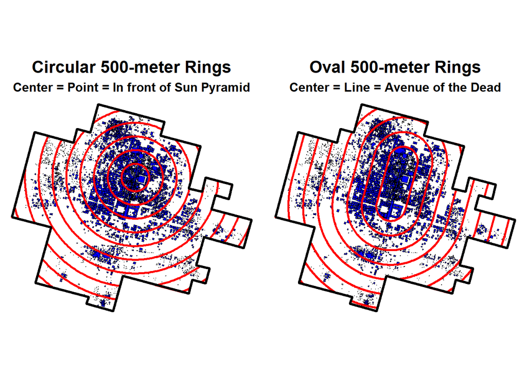

## 3.2 Create Ring Datasets

Using Function

```r
## Calculate Circular Rings Data

TeoRings_Circ <- CalcRingData(PolyData = Teo_Poly_Data, RingsPoly = RingsPoly_Circle,
    RingVersion = "Ring_Circle", output_arch_data = F, output_ring_data = T)

## Calculate Oval Rings Data

TeoRings_Oval <- CalcRingData(PolyData = Teo_Poly_Data, RingsPoly = RingsPoly_Oval,
    RingVersion = "Ring_Oval", output_arch_data = T, output_ring_data = T)

## Save List output items as separate objects
Teo_ArchPoly_Data <- TeoRings_Oval[[2]]
TeoRings_Oval <- TeoRings_Oval[[1]]
```

## 3.3 Ring Dataset Variables

| Column | Variable | Units | Description |
| --- | --- | --- | --- |
| **A) Ring Distances** |  |  |  |
| 1 | Ring | NA [ordinal] | Sequential order of concentric ring (increasing outward from 1) |
| 2 | MinRingDist | meters | Distance from urban core to inner ring edge |
| 3 | MedRingDist | meters | Distance from urban core to ring midpoint |
| 4 | MaxRingDist | meters | Distance from urban core to outter ring edge |
| **B) Overall Spatial Demography** |  |  |  |
| 5 | Ring_Area | ha | Total area of ring |
| 6 | Pop_TOT | persons | Total population of ring |
| 7 | Popdens_TOT | persons/ha | Overall population density of ring |
| **C) Land Use Classes** |  |  |  |
| 8 | DStr_TOT | count | Total count of domestic structures within ring |
| 9 | Area_DStr | ha | Total area of domestic structures within ring |
| 10 | NonCC_Feat_TOT | count | Total count of Non-CC features within ring |
| 11 | NonCC_Feat_Area | ha | Total area of Non-CC features within ring |
| 12 | NonCCDStr_TOT | count | Total count of features within ring that are neither CC features nor domestic structures |
| 13 | NonCCDStr_Area | ha | Total area of features within ring that are neither CC features nor domestic structures |
| 14 | OB | count | Total count of Outbuilding features within ring |
| 15 | OB_Area | ha | Total area of Outbuilding features within ring |
| 16 | Unoccu | count | Total count of Unoccupied features within ring |
| 17 | Unoccu_Area | ha | Total area of Unoccupied features within ring |
| 18 | DomPlat | count | Total count of Domestic Platform features within ring |
| 19 | DomPlat_Area | ha | Total area of Domestic Platform features within ring |
| 20 | Unk | count | Total count of Unknown features within ring |
| 21 | Unk_Area | ha | Total area of Unknown features within ring |
| 22 | CCStr | count | Total count of CC Structure features within ring |
| 23 | CCStrArea | ha | Total area of CC Structure features within ring |
| 24 | AoD | count | Total number of Avenue of the Dead features within ring |
| 25 | AoD_Area | ha | Total area of Avenue of the Dead features within ring |
| 26 | Plazas | count | Total count of Plaza features within ring |
| 27 | Plaza_Area | ha | Total area of Plaza features within ring |

[output cut: 124 more lines]

# 4 Export Datasets for Analysis

```r
write.csv(TeoRings_Circ, paste0(wd$data_f, "TeoRings_Circ.csv"))

write.csv(TeoRings_Oval, paste0(wd$data_f, "TeoRings_Oval.csv"))

writeOGR(Teo_ArchPoly_Data, paste0(wd$data_f, "Teo_ArchPoly_Data.gpkg"), "Teo_ArchPoly_Data",
    driver = "GPKG", overwrite_layer = TRUE)
```